# My R Markdown Primer

Saeed Rahman

April 13, 2026

#Introduction

R Markdown is a tool in RStudio that allows me to combine narrative text, R code, and mathematical expressions in a single document. It helps present analysis in a clean and organized format while keeping the code and results together.

This document uses the built-in **iris** dataset to demonstrate simple analysis, code chunks, and plotting in R Markdown.

# Narrative Paragraph

One useful feature of R Markdown is that it allows me to explain my work in plain language while also showing the exact code used to generate results. This makes the document easier to read and helps support reproducible analysis.

# LaTeX Math Expressions

Here is an example of inline math: $\alpha + \beta = \gamma$

Here is an example of a displayed equation:

$$\bar{x} = \frac{\sum_{i=1}^{n} x_i}{n}$$

# Load Dataset

```r
data(iris)
head(iris)
```

```
##   Sepal.Length Sepal.Width Petal.Length Petal.Width Species
## 1          5.1         3.5          1.4         0.2  setosa
## 2          4.9         3.0          1.4         0.2  setosa
## 3          4.7         3.2          1.3         0.2  setosa
## 4          4.6         3.1          1.5         0.2  setosa
## 5          5.0         3.6          1.4         0.2  setosa
## 6          5.4         3.9          1.7         0.4  setosa
```

# Summary Statistics

```r
summary(iris)
```

```
##   Sepal.Length    Sepal.Width     Petal.Length    Petal.Width
##  Min.   :4.300   Min.   :2.000   Min.   :1.000   Min.   :0.100
##  1st Qu.:5.100   1st Qu.:2.800   1st Qu.:1.600   1st Qu.:0.300
##  Median :5.800   Median :3.000   Median :4.350   Median :1.300
##  Mean   :5.843   Mean   :3.057   Mean   :3.758   Mean   :1.199
##  3rd Qu.:6.400   3rd Qu.:3.300   3rd Qu.:5.100   3rd Qu.:1.800
##  Max.   :7.900   Max.   :4.400   Max.   :6.900   Max.   :2.500
##        Species
##  setosa    :50
##  versicolor:50
##  virginica :50
##
##
##
```

# Simple Analysis

```r
mean(iris$Sepal.Length)
```

```
## [1] 5.843333
```

```r
mean(iris$Petal.Length)
```

```
## [1] 3.758
```

# Plot

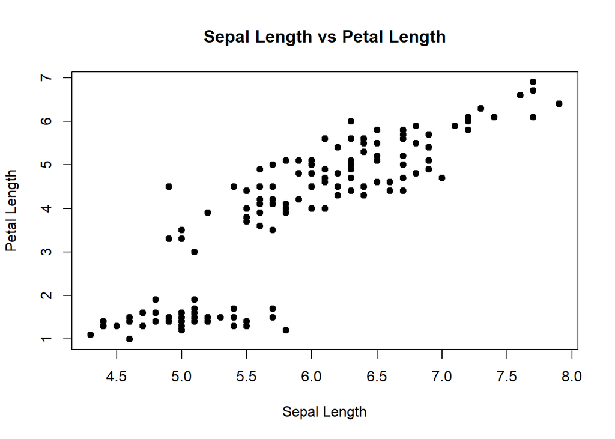

```r
plot(iris$Sepal.Length, iris$Petal.Length,
     main = "Sepal Length vs Petal Length",
     xlab = "Sepal Length",
     ylab = "Petal Length",
     pch = 19)
```

# Reflection

Using R Markdown was helpful because it allowed me to combine code, text, and results in one document. It is more efficient than writing a plain report because everything updates automatically when the code is run. One challenge I faced was formatting code chunks correctly and ensuring the document knitted without errors.